# Coursera - Practical Machine Learning Project

Stefan Krähenmann

Saturday, September 07, 2019

## Background

Using devices such as Jawbone Up, Nike FuelBand, and Fitbit it is now possible to collect a large amount of data about personal activity relatively inexpensively. These types of devices are part of the quantified self movement – a group of enthusiasts who take measurements about themselves regularly to improve their health, to find patterns in their behavior, or because they are tech geeks. One thing that people regularly do is quantify how much of a particular activity they do, but they rarely quantify how well they do it.

## The target of the project

In this project, the goal is to use data from accelerometers on the belt, forearm, arm, and dumbell of 6 participants. They were asked to perform barbell lifts correctly and incorrectly in 5 different ways. More information is available from the website here: http://web.archive.org/web/20161224072740/http:/groupware.les.inf.puc-rio.br/har (see the section on the Weight Lifting Exercise Dataset).

## Libraries

```r
library(caret)
library(parallel)
library(doParallel)
```

```r
library(ggplot2)
library(RANN)
library(rattle)
library(corrplot)
```

## Loading the data from URL

```r
training <- read.csv(url("https://d396qusza40orc.cloudfront.net/predmachlearn/pml-training.csv"),header=TRUE)
testdata <- read.csv(url("https://d396qusza40orc.cloudfront.net/predmachlearn/pml-testing.csv"),header=TRUE)
```

# General overview of the dataset

```r
dim(training)
```

```
## [1] 19622   160
```

```r
str(training)
```

```
## 'data.frame':    19622 obs. of  160 variables:
##  $ X                       : int  1 2 3 4 5 6 7 8 9 10 ...
##  $ user_name               : Factor w/ 6 levels "adelmo","carlitos",..: 2 2 2 2 2 2 2 2 2 2 ...
##  $ raw_timestamp_part_1    : int  1323084231 1323084231 1323084231 1323084232 1323084232 1323084232 1323084232 1323084232 1323084232 1323084232 ...
##  $ raw_timestamp_part_2    : int  788290 808298 820366 120339 196328 304277 368296 440390 484323 484434 ...
##  $ cvtd_timestamp          : Factor w/ 20 levels "02/12/2011 13:32",..: 9 9 9 9 9 9 9 9 9 9 ...
##  $ new_window              : Factor w/ 2 levels "no","yes": 1 1 1 1 1 1 1 1 1 1 ...
##  $ num_window              : int  11 11 11 12 12 12 12 12 12 12 ...
##  $ roll_belt               : num  1.41 1.41 1.42 1.48 1.48 1.45 1.42 1.42 1.43 1.45 ...
##  $ pitch_belt              : num  8.07 8.07 8.07 8.05 8.07 8.06 8.09 8.13 8.16 8.17 ...
##  $ yaw_belt                : num  -94.4 -94.4 -94.4 -94.4 -94.4 -94.4 -94.4 -94.4 -94.4 -94.4 ...
##  $ total_accel_belt        : int  3 3 3 3 3 3 3 3 3 3 ...
##  $ kurtosis_roll_belt      : Factor w/ 397 levels "","-0.016850",..: 1 1 1 1 1 1 1 1 1 1 ...
##  $ kurtosis_picth_belt     : Factor w/ 317 levels "","-0.021887",..: 1 1 1 1 1 1 1 1 1 1 ...
##  $ kurtosis_yaw_belt       : Factor w/ 2 levels "","#DIV/0!": 1 1 1 1 1 1 1 1 1 1 ...
```

[output cut: 86 more lines]

## Data preparation

The training dataset comprises of 19622 observations on 160 columns. Many columns have NA values or blank values on almost every observation.

```r
ind.na <- which(apply(is.na(training),c(2),mean) > .95) # check for missing data
length(ind.na) # number of predictors with high fraction of missing values
```

```
## [1] 67
```

```r
ind.nzv <- nearZeroVar(training) # check for data variance
length(ind.nzv) # number of predictors with low variability
```

```
## [1] 60
```

The first seven columns give information about the participants of the test and timestamps. They will also not be taken into account.

```r
# Combine the indexes of  columns having at least 95% of missing values, low varoance and the first 7 columns
ind.remove <- unique(c(ind.na, ind.nzv, 1:7))
training <- training[,-ind.remove]
name <- names(training)
```

# Partition the training dataset into new training and validtion dataset

```r
set.seed(1201)
inTrain <- createDataPartition(training$classe, p=.7, list=F)
trainingPart <- training[inTrain,]
validationPart <- training[-inTrain,]
dim(trainingPart)
```

```
## [1] 13737    53
```

```r
dim(validationPart)
```

```
## [1] 5885   53
```

This allows for an in sample validation of the machine learning algorithms. The new training dataset amounts to 70 percent of the original training dataset.

## Model buidling

For this project I used three different models, classification trees, random forests and generalized boosted models for prediction. 1.classification trees 2.random forests 3.Generalized Boosted Model

Cross-validation is used with 5 folds to limit the effects of overfitting and to improve the efficicency of the models. As relatievly complex machine learning algorithms are tested on a large dataset with many predictors, the processing time can be large. Therefor, calculations are done parallelly. All this is handelded by the parameter “trainingControl” which is then passed to caret’s “train” function.

```r
myControl <- trainControl(method = "cv",
                           number = 5,
                           allowParallel = TRUE,
                           verboseIter = FALSE)
# Allow for parallel calculations
cluster <- makeCluster(detectCores() - 3) # leave 3 core for OS
registerDoParallel(cluster)
```

## Prediction with classification trees

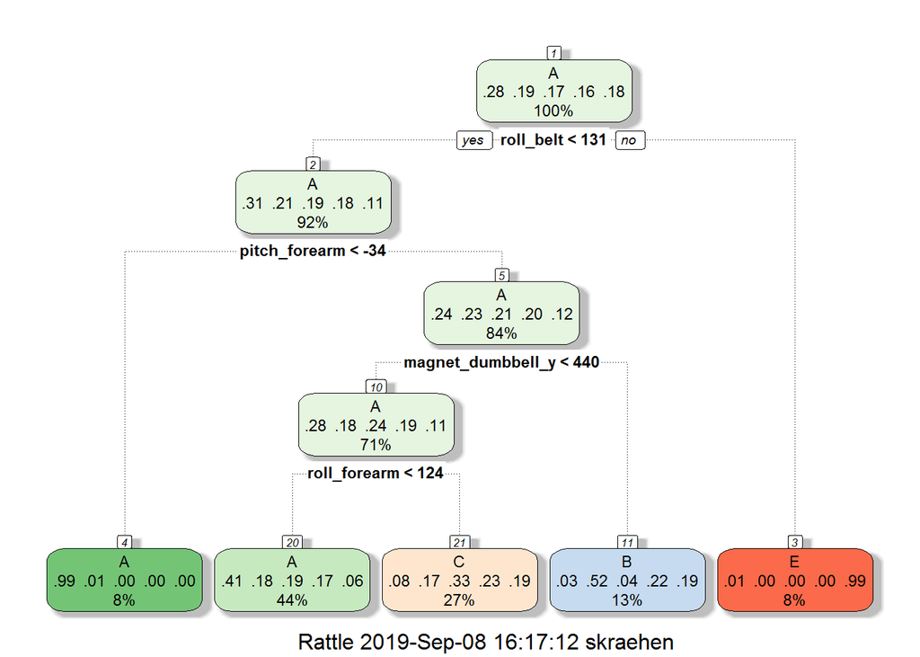

```r
set.seed(12)
model_tree <- train(classe~., trainingPart, method="rpart", trControl = myControl, tuneLength=3)
fancyRpartPlot(model_tree$finalModel)
```

```r
trainpred.tree <- predict(model_tree,newdata=trainingPart)
confMat.tree <- confusionMatrix(trainingPart$classe,trainpred.tree)
# display confusion matrix and model accuracy
confMat.tree$table
```

```
##           Reference
## Prediction    A    B    C    D    E
##          A 3548   52  295    0   11
##          B 1118  906  634    0    0
##          C 1116   73 1207    0    0
##          D  996  390  866    0    0
##          E  361  333  693    0 1138
```

```r
train_acc.tree <- confMat.tree$overall[1]
train_acc.tree # show accuracy
```

```
##  Accuracy
## 0.4949407
```

The accuracy of this first model is very low (49 %). This means that the outcome class will not be predicted very well using this model.

## Prediction with random forest

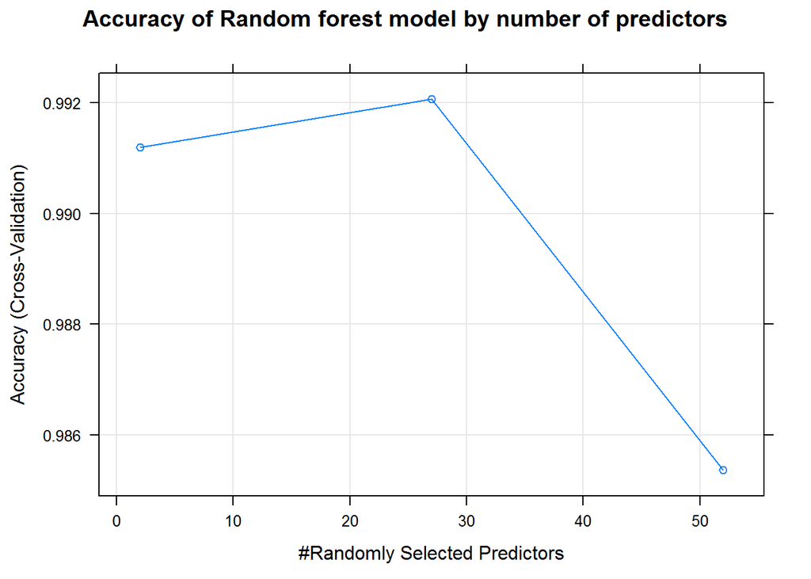

```r
set.seed(100)
model_rf <- train(classe~., trainingPart, method="rf", trControl = myControl, tuneLength=3, verbose=FALSE)
plot(model_rf,main="Accuracy of Random forest model by number of predictors")
```

```r
trainpred.rf <- predict(model_rf,newdata=trainingPart)
confMat.rf <- confusionMatrix(trainingPart$classe,trainpred.rf)
# display confusion matrix and model accuracy
confMat.rf$table
```

```
##           Reference
## Prediction    A    B    C    D    E
##          A 3906    0    0    0    0
##          B    0 2658    0    0    0
##          C    0    0 2396    0    0
##          D    0    0    0 2252    0
##          E    0    0    0    0 2525
```

```r
train_acc.rf <- confMat.rf$overall[1]
train_acc.rf # show accuracy
```

```
## Accuracy
##        1
```

```r
names(model_rf$finalModel) # show names of chosen predictors
```

```
##  [1] "call"            "type"            "predicted"
##  [4] "err.rate"        "confusion"       "votes"
##  [7] "oob.times"       "classes"         "importance"
## [10] "importanceSD"    "localImportance" "proximity"
## [13] "ntree"           "mtry"            "forest"
## [16] "y"               "test"            "inbag"
## [19] "xNames"          "problemType"     "tuneValue"
## [22] "obsLevels"       "param"
```

```r
# Compute the variable importance
MostImpVars <- varImp(model_rf)
MostImpVars
```

```
## rf variable importance
##
##   only 20 most important variables shown (out of 52)
##
##                      Overall
## roll_belt             100.00
## pitch_forearm          61.36
## yaw_belt               54.96
## magnet_dumbbell_y      44.13
## magnet_dumbbell_z      43.14
## pitch_belt             42.61
## roll_forearm           41.74
## accel_dumbbell_y       22.11
## accel_forearm_x        18.32
## roll_dumbbell          16.83
## magnet_dumbbell_x      16.11
## magnet_belt_z          15.25
## magnet_forearm_z       14.18
## total_accel_dumbbell   13.64
## accel_belt_z           13.43
## magnet_belt_y          12.98
## accel_dumbbell_z       12.67
## yaw_arm                11.27
## magnet_belt_x          10.64
## gyros_belt_z           10.01
```

## Prediction with gradient boosting

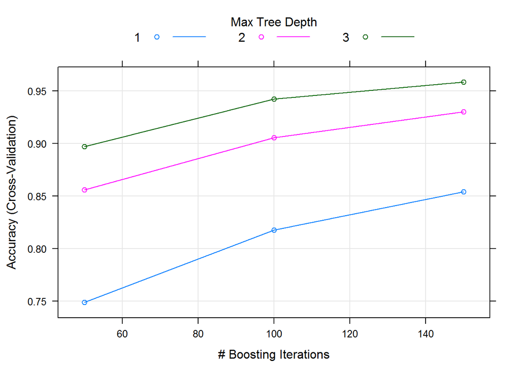

```r
set.seed(35)
model_gbm <- train(classe~., trainingPart, method="gbm", trControl = myControl, tuneLength=3, verbose=FALSE)
plot(model_gbm)
```

```r
trainpred.gbm <- predict(model_gbm,newdata=trainingPart)
confMat.gbm <- confusionMatrix(trainingPart$classe,trainpred.gbm)
# display confusion matrix and model accuracy
confMat.gbm$table
```

```
##           Reference
## Prediction    A    B    C    D    E
##          A 3875   24    1    5    1
##          B   57 2549   49    3    0
##          C    0   59 2306   26    5
##          D    1    3   53 2183   12
##          E    3   19   15   34 2454
```

```r
train_acc.gbm <- confMat.gbm$overall[1]
train_acc.gbm # show accuracy
```

```
##  Accuracy
## 0.9730654
```

Also prediction with gradient boosting method is high (97 %).

```r
# Predict using validation dataset
valpred.tree <- predict(model_tree,newdata=validationPart)
valpred.rf <- predict(model_rf,newdata=validationPart)
valpred.gbm <- predict(model_gbm,newdata=validationPart)

# accuracy with classification tree
val_acc.tree <- confusionMatrix(validationPart$classe,valpred.tree)$overall["Accuracy"]
val_acc.rf <- confusionMatrix(validationPart$classe,valpred.rf)$overall["Accuracy"]
val_acc.gbm <- confusionMatrix(validationPart$classe,valpred.gbm)$overall["Accuracy"]
```

# Compare in sample error with out of sample error

```r
df <- round(rbind(c(train_acc.tree, train_acc.rf, train_acc.gbm), c(val_acc.tree, val_acc.rf, val_acc.gbm)),2)
row.names(df) <- c("in-sample", "out-of-sample")
colnames(df) <- c("tree","rf","gbm")
#df
```

|  | tree | rf | gbm |
| --- | --- | --- | --- |
| in-sample | 0.49 | 1.00 | 0.97 |
| out-of-sample | 0.50 | 0.99 | 0.97 |

## Application of the random forest model to the test dataset

```r
prediction_final <- predict(model_rf, newdata=testdata[,-ind.remove])
prediction_final
```

```
##  [1] B A B A A E D B A A B C B A E E A B B B
## Levels: A B C D E
```

```r
# Unregister cluster for parallel calculation
stopCluster(cluster)
registerDoSEQ()
```